## title: "Global Educational Inequality: UNICEF Data Analysis" format: html: embed-resources: true code-fold: true execute: echo: false

# Introduction

Education is a fundamental human right and a critical driver of personal and societal development. However, despite global progress, millions of children and adolescents remain excluded from the education system. Understanding where and why these gaps exist is crucial for designing effective interventions.

This report explores global patterns in educational access by analyzing out-of-school rates for the year 2020. Using UNICEF data, we examine how economic prosperity (GDP per capita) and regional differences influence the likelihood of children being out of school.

## 🚨 Top 10 Countries with Highest Out-of-School Rates (2020)

The following bar chart highlights the ten countries with the highest rates of children out of school in 2020, illustrating critical areas for international intervention and support.

The chart also reveals that countries like Senegal, Burkina Faso, and Tuvalu face the highest out-of-school rates, exceeding 60%. Gender disparities are noticeable, with slight variations between male and female rates across countries. These findings highlight urgent educational challenges in specific regions, emphasizing the need for targeted global efforts to ensure inclusive schooling for all children.

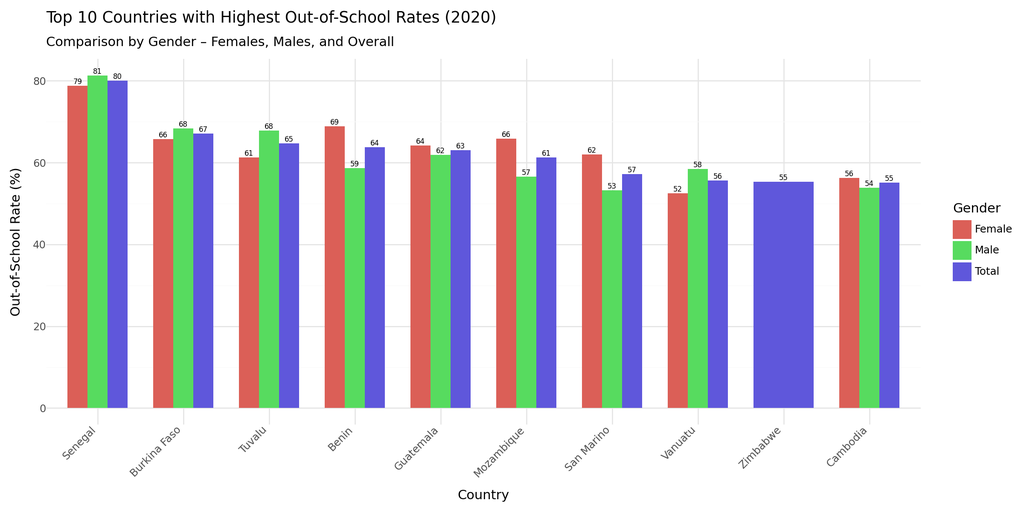

```python
import pandas as pd
import plotnine as p9

# Load the dataset
indicator = pd.read_csv("/content/unicef_indicator_1.csv")

# Filter for 2020 and drop missing values
df_2020 = indicator[(indicator['time_period'] == 2020) & (indicator['obs_value'].notna())]

# Get top 10 countries by Total rate
top_total = (
    df_2020[df_2020['sex'] == 'Total']
    .sort_values(by='obs_value', ascending=False)
    .head(10)
    .copy()
)

# Get all gender data for those countries
top_countries = top_total['country'].tolist()
top10 = df_2020[df_2020['country'].isin(top_countries)].copy()

# Set the country order to match Total ranking
top10['country'] = pd.Categorical(top10['country'], categories=top_total['country'], ordered=True)

# Plot with grouped bars and labels
plot = (
    p9.ggplot(top10, p9.aes(x='country', y='obs_value', fill='sex')) +
    p9.geom_bar(stat='identity', position='dodge', width=0.7) +
    p9.geom_text(
        p9.aes(label='obs_value'),
        position=p9.position_dodge(width=0.7),
        va='bottom',
        size=6,
        format_string='{:.0f}'
    ) +
    p9.labs(
        title='Top 10 Countries with Highest Out-of-School Rates (2020)',
        subtitle='Comparison by Gender – Females, Males, and Overall',
        x='Country',
        y='Out-of-School Rate (%)',
        fill='Gender'
    ) +
    p9.theme_minimal() +
    p9.theme(
        figure_size=(12, 6),
        axis_text_x=p9.element_text(angle=45, hjust=1),
        legend_position='right'
    )
)

plot
```

[figure not shown]

```python
# 📈 Global Trend Over Time

# Calculate the world average by year
global_trend = (
    indicator[indicator['sex'] == 'Total']
    .groupby('time_period')['obs_value']
    .mean()
    .reset_index()
)

# Plot the trend
global_trend_plot = (
    p9.ggplot(global_trend, p9.aes(x='time_period', y='obs_value')) +
    p9.geom_line(color="blue") +
    p9.geom_point(color="red") +
    p9.labs(
        title="Global Trend of Out-of-School Rates (2014–2020)",
        x="Year",
        y="Average Out-of-School Rate (%)"
    ) +
    p9.theme(figure_size=(10, 5))
)

global_trend_plot
```

## 🗺️ Regional Differences in Out-of-School Rates (2020)

The regional map reveals stark disparities in school access across the globe in 2020. Sub-Saharan Africa and parts of South Asia show the highest out-of-school rates, indicated by darker blue shades. In contrast, countries in Europe, North America, and parts of East Asia show significantly lower rates. This highlights the urgent need for targeted interventions in regions most affected by educational exclusion.

```python
import pandas as pd
import plotly.express as px

# Load the UNICEF indicator data
indicator = pd.read_csv("/content/unicef_indicator_1.csv")

# Filter for 2020 and 'Total' gender
df_2020 = indicator[
    (indicator['time_period'] == 2020) &
    (indicator['sex'] == 'Total') &
    (indicator['obs_value'].notna())
]

# Create the Choropleth map
fig = px.choropleth(
    df_2020,
    locations="alpha_3_code",        # ISO-3 country codes
    color="obs_value",               # Out-of-school rate
    hover_name="country",            # Hover tooltip shows country name
    color_continuous_scale=px.colors.sequential.Blues,
    title="🌍 Regional Differences in Out-of-School Rates (2020)<br><sup>Higher rates shown in darker blue. Localized interventions needed.</sup>",
    projection="natural earth",      # Looks more like a real globe
)

# Update layout for cleaner background
fig.update_layout(
    geo=dict(
        showframe=False,
        showcoastlines=True,           # Add coastlines for better world background
        coastlinecolor="LightGray",
        showland=True,
        landcolor="whitesmoke",         # Make land slightly visible
        showocean=True,
        oceancolor="lightblue"          # Make ocean light blue
    ),
    margin={"r":0,"t":50,"l":0,"b":0},
    coloraxis_colorbar=dict(
        title="Out-of-School<br>Rate (%)"
    )
)

# Show the plot
fig.show()
```

[interactive chart not shown]

## 📊 Regional Disparities in Out-of-School Rates (2020)

In 2020, South Asia recorded the highest average out-of-school rate at 40%, followed by the "Other" category at 30% and the Middle East & North Africa at 25%. Latin America & the Caribbean had the lowest rate at 10%. This highlights stark regional inequalities, emphasizing that South Asia and parts of Africa require intensified educational investments and policy focus.

```python
import pandas as pd
import plotly.express as px

# Reload dataset
indicator = pd.read_csv("/content/unicef_indicator_1.csv")

# Filter for 2020 and 'Total'
df_2020 = indicator[
    (indicator['time_period'] == 2020) &
    (indicator['sex'] == 'Total') &
    (indicator['obs_value'].notna())
]

# Region mapping
region_mapping = {
    'India': 'South Asia', 'Pakistan': 'South Asia', 'Bangladesh': 'South Asia', 'Nepal': 'South Asia',
    'Nigeria': 'Sub-Saharan Africa', 'Ethiopia': 'Sub-Saharan Africa', 'Kenya': 'Sub-Saharan Africa',
    'South Africa': 'Sub-Saharan Africa', 'Uganda': 'Sub-Saharan Africa', 'Tanzania': 'Sub-Saharan Africa',
    'China': 'East Asia & Pacific', 'Indonesia': 'East Asia & Pacific', 'Philippines': 'East Asia & Pacific',
    'Vietnam': 'East Asia & Pacific', 'Thailand': 'East Asia & Pacific',
    'Brazil': 'Latin America & Caribbean', 'Mexico': 'Latin America & Caribbean', 'Argentina': 'Latin America & Caribbean',
    'Colombia': 'Latin America & Caribbean', 'Peru': 'Latin America & Caribbean',
    'Egypt': 'Middle East & North Africa', 'Morocco': 'Middle East & North Africa', 'Algeria': 'Middle East & North Africa',
    'United Kingdom': 'Europe', 'Germany': 'Europe', 'France': 'Europe', 'Italy': 'Europe', 'Spain': 'Europe',
    'United States': 'North America', 'Canada': 'North America',
}

# Apply mapping
df_2020['region'] = df_2020['country'].map(region_mapping)
df_2020['region'] = df_2020['region'].fillna('Other')

# Group by region
region_grouped = df_2020.groupby('region')["obs_value"].mean().reset_index()

# Sort
region_grouped = region_grouped.sort_values(by='obs_value', ascending=True)

# Create fancier horizontal bar chart
fig = px.bar(
    region_grouped,
    y="region",
    x="obs_value",
    title="🌍 Regional Disparities in Out-of-School Rates (2020)",
    color="obs_value",
    color_continuous_scale="Blues",
    text_auto='.2s',
    orientation='h',
)

fig.update_traces(
    textfont_size=14,
    textangle=0,
    textposition="outside",
    cliponaxis=False,
    marker_line_color='black',
    marker_line_width=1.5
)

fig.update_layout(
    xaxis_title="Average Out-of-School Rate (%)",
    yaxis_title="Region",
    title_font_size=24,
    title_x=0.5,  # Center title
    font=dict(
        family="Arial",
        size=14,
        color="black"
    ),
    plot_bgcolor='white',
    paper_bgcolor='white',
    coloraxis_showscale=False
)

fig.show()
```

[interactive chart not shown]

## 💰 Wealth vs. 📚 Education Access (2020)

```python
# Merge the datasets on 'country' instead of 'alpha_3_code'
merged_data = pd.merge(
    df_2020[['country', 'obs_value']],
    gdp_data[['country', 'obs_value']].rename(columns={'obs_value': 'gdp_per_capita'}),
    how='inner',
    on='country'
)

# Show merged data sample
print(merged_data.head(10))
```

[output not shown]

```python
import plotly.express as px

fig = px.scatter(
    merged_data,
    x='gdp_per_capita',
    y='obs_value',
    hover_name='country',
    trendline='ols',  # Add a regression trendline
    labels={
        'gdp_per_capita': 'GDP per Capita (USD)',
        'obs_value': 'Out-of-School Rate (%)'
    },
    title="💰 Economic Inequality vs. 📚 Out-of-School Rates (2020)",
    template="plotly_white"  # cleaner background
)

# Fancier layout tweaks
fig.update_layout(
    plot_bgcolor='white',
    xaxis=dict(
        showgrid=True,
        gridcolor='lightgrey',
        title_font=dict(size=14),
        tickfont=dict(size=12)
    ),
    yaxis=dict(
        showgrid=True,
        gridcolor='lightgrey',
        title_font=dict(size=14),
        tickfont=dict(size=12)
    )
)

fig.show()
```

[output not shown]

# Conclusion

This analysis of global out-of-school rates in 2020 highlights both progress and persistent inequality in access to education.  
While wealthier countries have made remarkable strides towards universal education, many low- and middle-income countries continue to face serious challenges.

To achieve universal education goals, the international community must continue investing in infrastructure, targeted policies, and programs that address the barriers to schooling — especially in economically disadvantaged regions.  
The path forward requires coordinated global efforts to ensure every child has the opportunity to access quality education, regardless of where they live.

This report also highlights the critical link between economic prosperity and access to education. While some regions have made progress, many countries still face significant barriers to universal schooling. Continued efforts are essential to bridge global education gaps

# Reflection and Insights

This analysis highlights the deep inequalities that persist in global education access. Wealth disparities, regional differences, and national economic challenges are strongly linked to higher out-of-school rates. Understanding these patterns is critical for shaping effective education policies and targeted interventions. Addressing educational inequality is not just a moral imperative, but also essential for fostering global development, social equity, and long-term economic growth.